# Airbnb Data Insights

- Introduction
- Obtaining Data
- Exploratory Data Analysis (EDA)
- Recommendation for our Friend X
- Recommendation for Y in Chicago
- Conclusion

### Package Imports

```python
import sqlite3
from bs4 import BeautifulSoup
import pandas as pd
import requests
from io import BytesIO
import matplotlib.pyplot as plt
import seaborn as sns
import plotly.express as px
import plotly.graph_objects as go
import nltk
from nltk.sentiment.vader import SentimentIntensityAnalyzer
import ipywidgets as widgets
from IPython.display import display, clear_output
import plotly.graph_objs as go
from matplotlib.ticker import AutoMinorLocator
import numpy as np
import matplotlib.pyplot as plt

from sklearn.linear_model import LinearRegression
from sklearn.neighbors import KNeighborsRegressor
from sklearn.model_selection import train_test_split, GridSearchCV
from sklearn.metrics import mean_squared_error, r2_score

nltk.download('vader_lexicon')
```

```
True
```

```python
import plotly.offline as py
py.init_notebook_mode(connected=True)
```

### File Paths

```python
# Change to local filepaths where relevant files are stored
filepath_html = "inside_airbnb.html"
filepath = '/Users/name/Downloads/airbnb_data.db'
filepath_chicago = 'chicago.csv'
filepath_city_df = 'city_data_df.csv'
```

## Introduction

In a world where Airbnb has revolutionized urban accommodation, our study embarks on a journey to untangle the complexities of its market dynamics across major North American cities. At the heart of this exploration is your friend X from Chicago, who aspires to monetize his property through Airbnb. With numerous hosting options at his disposal and uncertainties surrounding the best approach, X turns to you, seeking insights drawn from your expertise in data visualization and analysis. This report aims to equip X with a strategic understanding of Airbnb's pricing, supply, and demand trends, tailoring these insights to empower him in navigating the competitive landscape of Airbnb hosting in a bustling city like Chicago.

Our study also caters to the needs of your friend Y, who, intrigued by Chicago's allure, is considering it for his next travel destination. Unfamiliar with the city and lacking personal recommendations, Y has turned to us for guidance in choosing the right Airbnb. Our analysis aims to provide Y with comprehensive insights into Chicago's Airbnb market, highlighting property features that influence the satisfaction of customers. This information will be invaluable in helping Y make an informed decision for a memorable and comfortable stay in Chicago.

## Obtaining Data

Data Source

Our primary data source for this investigation is the comprehensive Airbnb dataset available through "Inside Airbnb". This publicly accessible platform provides detailed listings for cities worldwide, encompassing critical variables such as pricing, location, host information, and reviews. Access to this dataset is facilitated via the following link: http://insideairbnb.com/get-the-data/.

Data Scraping and Aggregation

To capture the essence of Airbnb's impact across major American and Canadian cities, our approach began with a systematic scraping of datasets for each city listed on Inside Airbnb. While Inside Airbnb's scope extends globally, our focus necessitated the gathering of a diverse set of data points from numerous cities. Specifically, we have constructed a database with three distinct tables for each city. These tables contain reviews, nightly price data for individual units, and comprehensive listing details, including property type, location, host information, and room count. To accomplish this task, we begin by downloading the HTML file from http://insideairbnb.com/get-the-data/. Subsequently, we employ a straightforward scraping algorithm, utilizing beautifulsoup4, to extract and store the URLs of all the data tables found on the webpage, and exclude those not relevant to our analysis. The code for this process is illustrated below:

```python
# In this code chunk we extract all download URLs in "inside_airbnb.html", which contains the source code for "http://insideairbnb.com/get-the-data/"

def extract_csv_links(file_path):

    with open(file_path, 'r', encoding='utf-8') as file:
        contents = file.read()

    soup = BeautifulSoup(contents, 'html.parser')

    links = soup.find_all('a')

    csv_links = [link.get('href') for link in links if link.get('href') and link.get('href').endswith('.csv') or link.get('href').endswith('.gz')]

    return csv_links

csv_links_all = extract_csv_links(filepath_html)

csv_links = []

for link in csv_links_all:
    if not "neighbourhoods.csv" in link and not "visualisations/reviews.csv" in link and not "data/listings" in link:
        if "canada" in link or "united-states" in link: # Selecting only the tables for the US and Canada
            csv_links.append(link)
display(csv_links[:10])
```

```
['http://data.insideairbnb.com/united-states/ny/albany/2024-01-06/data/calendar.csv.gz',
 'http://data.insideairbnb.com/united-states/ny/albany/2024-01-06/data/reviews.csv.gz',
 'http://data.insideairbnb.com/united-states/ny/albany/2024-01-06/visualisations/listings.csv',
 'http://data.insideairbnb.com/united-states/nc/asheville/2023-12-18/data/calendar.csv.gz',
 'http://data.insideairbnb.com/united-states/nc/asheville/2023-12-18/data/reviews.csv.gz',
 'http://data.insideairbnb.com/united-states/nc/asheville/2023-12-18/visualisations/listings.csv',
 'http://data.insideairbnb.com/united-states/tx/austin/2023-12-15/data/calendar.csv.gz',
 'http://data.insideairbnb.com/united-states/tx/austin/2023-12-15/data/reviews.csv.gz',
 'http://data.insideairbnb.com/united-states/tx/austin/2023-12-15/visualisations/listings.csv',
 'http://data.insideairbnb.com/united-states/ma/boston/2023-12-18/data/calendar.csv.gz']
```

Once we a have a list of all relevant tables, our next step is to download them and subsequently create an SQL database from the acquired data. To derive suitable table names, we employ the extract_table_name() function, which uses the URL to systematically create names. We manage the construction and handling of the database using LightSQL for Python, while the actual downloads are executed using the requests library.

```python
# Note that running this code chunk takes 1+ hours depending on internet speed etc. The full data base is around 10GB in size.

# By splitting download URLs into parts we can systematically build table names
def extract_table_name(url):
    parts = url.split('/')
    country = parts[3]
    city = parts[5] if len(parts) > 7 else country
    category = parts[-2]
    file_name = parts[-1].split('.')[0]
    return f"{country}_{city}_{category}_{file_name}"


def download_csv(url):
    response = requests.get(url)
    response.raise_for_status()
    return BytesIO(response.content)

conn = sqlite3.connect(filepath)

csv_urls = csv_links

# Iterate through all relevant extracted URLs
for ind, url in enumerate(csv_urls):

    csv_content = download_csv(url) # Download the CSV

    table_name = extract_table_name(url) # Create a table name from the download URL
    print(table_name + " - Progress: " + str(round(ind*100/len(csv_urls),2)) + "%")

    df = pd.read_csv(csv_content, compression='gzip' if url.endswith('.gz') else None) # Store CSV as a data frame

    df.to_sql(table_name, conn, if_exists='replace', index=False) # Store data frame in data base

conn.close()
```

The resulting database is rather large, around 10GB in size, so we store it outside of our GitHub repository. As a quick check, we connect to the database using the specified path and retrieve the names of all the tables it contains.

```python
conn = sqlite3.connect(filepath)
cursor = conn.cursor()
cursor.execute("SELECT name FROM sqlite_master WHERE type='table';")
tables = [table[0] for table in cursor.fetchall()]
cursor.close()
conn.close()
display(tables[:10])
```

```
['united-states_albany_data_calendar',
 'united-states_albany_data_reviews',
 'united-states_albany_visualisations_listings',
 'united-states_asheville_data_calendar',
 'united-states_asheville_data_reviews',
 'united-states_asheville_visualisations_listings',
 'united-states_austin_data_calendar',
 'united-states_austin_data_reviews',
 'united-states_austin_visualisations_listings',
 'united-states_boston_data_calendar']
```

## Exploratory Data Analysis (EDA)

This section presents an exploratory data analysis of our dataset, with a particular focus on the data related to Chicago. We begin by examining the details and trends within the Chicago dataset, before broadening our analysis to include the entire data base. This approach allows us to understand the specifics of Chicago in the context of comparative data from other cities.

```python
# Connect to the data base to extract all three tables related to Chicago

conn = sqlite3.connect(filepath)

query = "SELECT name FROM sqlite_master WHERE type='table' AND name LIKE '%chicago%'"

cursor = conn.execute(query)
tables = [row[0] for row in cursor.fetchall()]

# Using a dictionary, we can store the data frames with their respective names in one object
chicago_dataframes = {}

for table in tables:
    query = f'SELECT * FROM "{table}"'
    chicago_dataframes[table] = pd.read_sql_query(query, conn)

conn.close()

# For simplicity, we store each of the three data frames under a shortened name
chicago_listings = chicago_dataframes['united-states_chicago_visualisations_listings']
chicago_calendar = chicago_dataframes['united-states_chicago_data_calendar']
chicago_reviews = chicago_dataframes['united-states_chicago_data_reviews']
```

- Listings Data (general information on the listings)

  We have a dataset with 8'949 entries and 18 columns, each representing a different attribute of the data. All entries have non-null values for most columns, except for:
  - `neighbourhood_group`: This column has no non-null values, indicating it's entirely empty.
  - `price`: There are some missing values since only 8'338 out of 8'949 entries are non-null.
  - `last_review` and `reviews_per_month`: These columns are related to customer reviews and have missing values, with non-null counts at 7'042, suggesting that not all listings have reviews.

  The data types are appropriate for each column with integers (`int64`) for identifiers and counts, floating-point numbers (`float64`) for latitude, longitude, price, and reviews per month, and strings for textual data like names and room types.

  The `price` variable reveals an average listing price of 173.17, though the substantial standard deviation of 1'112.35 suggests prices fluctuate widely across listings. The duration of stay required by hosts, indicated by the `minimum_nights` field, also seems to have a large spread, ranging from 1 to 1'125 nights. The `number_of_reviews` column highlights a significant discrepancy in guest feedback frequency, evidenced by a large standard deviation in relation to the mean, which indicates that while some properties are frequently reviewed, others may rarely be evaluated. Availability trends, as depicted by the `availability_365` column, show that properties are available for booking for an average of 189 days annually, with a subset offering year-round accessibility.

```python
chicago_listings.info()
chicago_listings.iloc[:,3:].describe()
```

```
<class 'pandas.core.frame.DataFrame'>
RangeIndex: 8949 entries, 0 to 8948
Data columns (total 18 columns):
 #   Column                          Non-Null Count  Dtype
---  ------                          --------------  -----
 0   id                              8949 non-null   int64
 1   name                            8949 non-null   object
 2   host_id                         8949 non-null   int64
 3   host_name                       8949 non-null   object
 4   neighbourhood_group             0 non-null      object
 5   neighbourhood                   8949 non-null   object
 6   latitude                        8949 non-null   float64
 7   longitude                       8949 non-null   float64
 8   room_type                       8949 non-null   object
 9   price                           8338 non-null   float64
 10  minimum_nights                  8949 non-null   int64
 11  number_of_reviews               8949 non-null   int64
 12  last_review                     7042 non-null   object
 13  reviews_per_month               7042 non-null   float64
 14  calculated_host_listings_count  8949 non-null   int64
 15  availability_365                8949 non-null   int64
 16  number_of_reviews_ltm           8949 non-null   int64
 17  license                         7278 non-null   object
dtypes: float64(4), int64(7), object(7)
memory usage: 1.2+ MB
```

|  | latitude | longitude | price | minimum_nights | number_of_reviews | reviews_per_month | calculated_host_listings_count | availability_365 | number_of_reviews_ltm |
| --- | --- | --- | --- | --- | --- | --- | --- | --- | --- |
| count | 8949.000000 | 8949.000000 | 8338.000000 | 8949.000000 | 8949.000000 | 7042.000000 | 8949.000000 | 8949.000000 | 8949.000000 |
| mean | 41.892335 | -87.661974 | 173.167786 | 15.881439 | 46.773159 | 1.834915 | 55.985361 | 189.932283 | 12.933624 |
| std | 0.062265 | 0.043951 | 1112.349527 | 41.144839 | 89.977542 | 1.858998 | 164.076829 | 140.088536 | 20.119904 |
| min | 41.646767 | -87.847243 | 7.000000 | 1.000000 | 0.000000 | 0.010000 | 1.000000 | 0.000000 | 0.000000 |
| 25% | 41.862740 | -87.685360 | 70.250000 | 2.000000 | 1.000000 | 0.480000 | 1.000000 | 45.000000 | 0.000000 |
| 50% | 41.896218 | -87.657240 | 115.000000 | 2.000000 | 14.000000 | 1.490000 | 3.000000 | 180.000000 | 4.000000 |
| 75% | 41.935150 | -87.630250 | 178.000000 | 32.000000 | 55.000000 | 2.710000 | 19.000000 | 339.000000 | 21.000000 |
| max | 42.022200 | -87.528420 | 99998.000000 | 1125.000000 | 3501.000000 | 56.200000 | 643.000000 | 365.000000 | 596.000000 |

- Calendar Data (price per night for each listing throughout the year)

  The most important variable here is `price`, which does not have any missing values. However, in order to transfrom it to a numeric variable, some data cleaning is necessary. The data frame has many observations: For each listing in Chicago, the price is noted for every night of the year, leading to a very long data structure.

```python
chicago_calendar['price'] = chicago_calendar['price'].str.replace('[$,]', '', regex=True).astype(float)
chicago_calendar['adjusted_price'] = chicago_calendar['adjusted_price'].str.replace('[$,]', '', regex=True).astype(float)

chicago_calendar.info(show_counts=True)
chicago_calendar.iloc[:,1:].describe()
```

```
<class 'pandas.core.frame.DataFrame'>
RangeIndex: 3266145 entries, 0 to 3266144
Data columns (total 7 columns):
 #   Column          Non-Null Count    Dtype
---  ------          --------------    -----
 0   listing_id      3266145 non-null  int64
 1   date            3266145 non-null  object
 2   available       3266145 non-null  object
 3   price           3266145 non-null  float64
 4   adjusted_price  1095 non-null     float64
 5   minimum_nights  3266145 non-null  int64
 6   maximum_nights  3266145 non-null  int64
dtypes: float64(2), int64(3), object(2)
memory usage: 174.4+ MB
```

|  | price | adjusted_price | minimum_nights | maximum_nights |
| --- | --- | --- | --- | --- |
| count | 3.266145e+06 | 1095.000000 | 3.266145e+06 | 3.266145e+06 |
| mean | 2.130728e+02 | 2919.074886 | 3.962939e+01 | 2.397378e+06 |
| std | 3.910774e+02 | 1721.986669 | 9.797773e+01 | 7.169986e+07 |
| min | 0.000000e+00 | 1030.000000 | 1.000000e+00 | 1.000000e+00 |
| 25% | 8.000000e+01 | 1617.000000 | 2.000000e+00 | 3.650000e+02 |
| 50% | 1.260000e+02 | 1955.000000 | 3.000000e+00 | 1.125000e+03 |
| 75% | 2.050000e+02 | 5040.000000 | 3.200000e+01 | 1.125000e+03 |
| max | 1.030000e+04 | 5600.000000 | 1.125000e+03 | 2.147484e+09 |

- Review Data (text-based customer reviews for the listings)

  This DataFrame contains all written reviews for the listed accommodations. The primary source of relevant is the `comments` column, which contains the actual written text of the reviews. To associate a review with other details related to the accommodation, we can utilize the `listing_id` to retrieve additional data from the "Listings Data" table.

```python
chicago_reviews.info()
chicago_reviews.describe()
```

```
<class 'pandas.core.frame.DataFrame'>
RangeIndex: 418573 entries, 0 to 418572
Data columns (total 6 columns):
 #   Column         Non-Null Count   Dtype
---  ------         --------------   -----
 0   listing_id     418573 non-null  int64
 1   id             418573 non-null  int64
 2   date           418573 non-null  object
 3   reviewer_id    418573 non-null  int64
 4   reviewer_name  418573 non-null  object
 5   comments       418444 non-null  object
dtypes: int64(3), object(3)
memory usage: 19.2+ MB
```

|  | listing_id | id | reviewer_id |
| --- | --- | --- | --- |
| count | 4.185730e+05 | 4.185730e+05 | 4.185730e+05 |
| mean | 1.140489e+17 | 4.369525e+17 | 1.662948e+08 |
| std | 2.663526e+17 | 4.015006e+17 | 1.470943e+08 |
| min | 2.384000e+03 | 4.982000e+03 | 6.500000e+01 |
| 25% | 1.565907e+07 | 4.837217e+08 | 4.282871e+07 |
| 50% | 2.939276e+07 | 4.927863e+17 | 1.215676e+08 |
| 75% | 4.885104e+07 | 8.319024e+17 | 2.566985e+08 |
| max | 1.041991e+18 | 1.054509e+18 | 5.509657e+08 |

We calculate a basic "sentiment score" for the text contained in the `comments` field as a simple demonstration of how text data can be utilized in our analysis. This score aims to assess the sentiment of a given text on a scale ranging from -1, indicating a "very negative" sentiment, to 1, signifying a "very positive" sentiment. The computation is based on the VADER dictionary from the nltk package. This simple method extracts sentiment by comparing words contained in text to a dictionary of terms with associated socring-values.

```python
sid = SentimentIntensityAnalyzer() # This creates an analyzer instance for our purpose (sentiment analysis based on VADER)

def compute_sentiment(text):
    if text is None:
        return 0
    return sid.polarity_scores(str(text))['compound'] # We use the polarity_scores() function to compute the VADER sentiment scores

chicago_reviews['sentiment_score'] = chicago_reviews['comments'].apply(compute_sentiment)
```

We can visualize this score in many ways. The plot below shows the average sentiment across all listings as a time series. A smoothed time trend is added for better readability. Further examples of using this sentiment score are available in the subsequent sections.

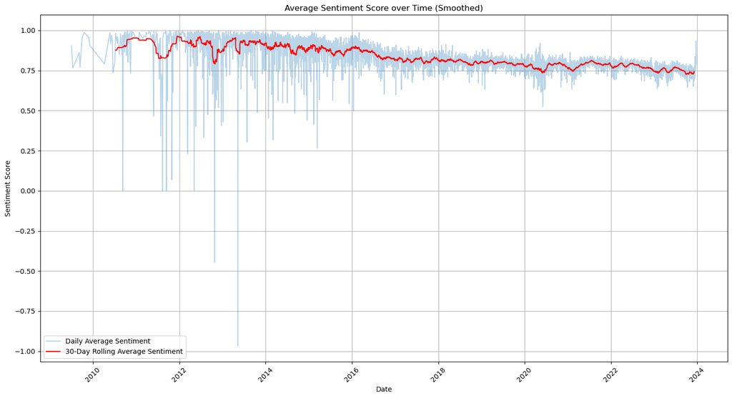

```python
chicago_reviews['date'] = pd.to_datetime(chicago_reviews['date'])

date_sentiment = chicago_reviews.groupby('date')['sentiment_score'].mean().reset_index()

rolling_window_size = 30
date_sentiment['rolling_avg_sentiment'] = date_sentiment['sentiment_score'].rolling(window=rolling_window_size, center=True).mean()

plt.figure(figsize=(15, 8))
plt.plot(date_sentiment['date'], date_sentiment['sentiment_score'], alpha=0.3, label='Daily Average Sentiment')
plt.plot(date_sentiment['date'], date_sentiment['rolling_avg_sentiment'], color='red', label=f'{rolling_window_size}-Day Rolling Average Sentiment')

plt.title('Average Sentiment Score over Time (Smoothed)')
plt.xlabel('Date')
plt.ylabel('Sentiment Score')
plt.legend()
plt.grid(True)
plt.tight_layout()
plt.xticks(rotation=45)
plt.show()
```

Comparing City Data

Now that we have illustrated what the data looks like for a given city, we want to explore further and use some of this data to compare the Airbnb listings between different locations. In our analysis, we compare Airbnb listings across various locations using data from three distinct city tables. This involves an approach where we calculate the average sentiment scores from reviews for each city. These scores are then integrated with geographical information to create an interactive map, visually representing the findings. Similarly, we merge pricing information from the 'calendar' tables with geographic data, constructing a similar map that showcases price variations. Additionally, for an interesting twist, we identify the most common host name in each city, along with its frequency. A name's prevalence may be due to its commonality or a single host's numerous listings in that city. This comprehensive approach offers a unique perspective on Airbnb's landscape in different cities. Instead of running the cell below, the resulting file can be downloaded from GitHub or Google Drive as well ("city_data_df.csv").

```python
# Note that this code chunk takes a long time to run (~45 minutes) due to the number of cities and large file sizes

conn = sqlite3.connect(filepath)

sid = SentimentIntensityAnalyzer()

# We need all three available tables, hence we create queries for calendar, reviews, and listings tables
query_prices = "SELECT name FROM sqlite_master WHERE type='table' AND name LIKE '%_calendar';"
query_visualisations = "SELECT name FROM sqlite_master WHERE type='table' AND name LIKE '%_listings';"
query_reviews = "SELECT name FROM sqlite_master WHERE type='table' AND name LIKE '%_reviews';"

price_tables = pd.read_sql_query(query_prices, conn)
visualisation_tables = pd.read_sql_query(query_visualisations, conn)
review_tables = pd.read_sql_query(query_reviews, conn)

# In this dictionary we can store city names together with the computed and extracted attributes
city_data = {}

# We iterate through each table type and extract the necessary information
for table_name in review_tables['name']:
    city = table_name.split('_')[1]

    df_reviews = pd.read_sql_query(f'SELECT comments FROM "{table_name}"', conn)
    df_reviews['sentiment_score'] = df_reviews['comments'].apply(lambda x: sid.polarity_scores(x)['compound'] if pd.notnull(x) else 0)

    if city not in city_data:
        city_data[city] = {'sentiment_score': None, 'mean_price': None, 'Latitude': None, 'Longitude': None, 'number_of_reviews': 0}

    city_data[city]['sentiment_score'] = df_reviews['sentiment_score'].dropna().mean()
    city_data[city]['number_of_reviews'] = len(df_reviews)

for table_name in price_tables['name']:
    city = table_name.split('_')[1]

    df_price = pd.read_sql_query(f'SELECT price FROM "{table_name}"', conn)
    df_price['price'] = df_price['price'].str.replace('[$,]', '', regex=True).astype(float)

    city_data[city]['mean_price'] = df_price['price'].dropna().mean()

for table_name in visualisation_tables['name']:
    city = table_name.split('_')[1]

    df_listings = pd.read_sql_query(f'SELECT latitude, longitude, host_name FROM "{table_name}"', conn)

    city_data[city]['Latitude'] = df_listings['latitude'].dropna().mean()
    city_data[city]['Longitude'] = df_listings['longitude'].dropna().mean()
    city_data[city]['CommonName'] = df_listings['host_name'].value_counts().idxmax()
    city_data[city]['CommonNameFreq'] = df_listings['host_name'].value_counts()[0]

conn.close()

# To simplify plotting we transform the dictionary into a data frame
city_data_df = pd.DataFrame.from_dict(city_data, orient='index').reset_index().rename(columns={'index': 'City'})

city_data_df.to_csv('city_data_df.csv', index=False)
```

The interactive plots created using the results from above are depicted below:

```python
# To load the downloaded data if necessary
city_data_df = pd.read_csv(filepath_city_df)
```

```python
fig = px.scatter_geo(city_data_df.dropna(subset=['mean_price']),
                     lat='Latitude',
                     lon='Longitude',
                     color='mean_price',
                     hover_name='City',
                     size= (city_data_df.dropna()['mean_price']+1),
                     projection="natural earth",
                     title='Average Price per Night per City')

fig.update_layout(
    title='Average Price per Night per City',
    title_x=0.5,
    margin=dict(t=50, b=0, l=0, r=0)
)
fig.show()
```

[interactive chart not shown]

```python
fig = px.scatter_geo(city_data_df.dropna(subset=['sentiment_score']),
                     lat='Latitude',
                     lon='Longitude',
                     color='sentiment_score',
                     hover_name='City',
                     size= (city_data_df['sentiment_score']+1)**20,
                     projection="natural earth",
                     title='Average Sentiment Score per City')

fig.update_layout(
    title='Average Sentiment Score per City',
    title_x=0.5,
    margin=dict(t=50, b=0, l=0, r=0)
)

fig.show()
```

[interactive chart not shown]

```python
city_data_df['hover_info'] = city_data_df['CommonName'] + " - " + city_data_df['CommonNameFreq'].astype(str)

fig = px.scatter_geo(city_data_df,
                     lat='Latitude',
                     lon='Longitude',
                     hover_name = 'hover_info',
                     text='hover_info',
                     projection="natural earth",
                     title='Most Common Host Name and Frequency')

fig.update_layout(
    title='Most Common Host Name and Frequency',
    title_x=0.5,
    margin=dict(t=50, b=0, l=0, r=0)
)
```

[interactive chart not shown]

To conclude this introduction to our data and some of the approaches we use, the following visualization depicts the average price against the average sentiment score for each city. This comparison may highlight cities that excel in offering value in terms of both price and positive reviews. The bubble size increases with the number of reviews, as this might be an indication of the quality of the sentiment score.

```python
city_data_df['number_of_reviews_scaled'] = city_data_df['number_of_reviews']**(1/3)

fig = go.Figure()

fig.add_trace(
    go.Scatter(
        x=city_data_df['mean_price'],
        y=city_data_df['sentiment_score'],
        mode='markers',
        marker=dict(
            size=city_data_df['number_of_reviews_scaled']**0.75,
            color=city_data_df['sentiment_score'],
            colorscale='Viridis',
            showscale=True
        ),
        text=city_data_df['City']
    )
)
fig.update_layout(
    title='Average Price vs. Sentiment Score per City',
    xaxis_title='Average Price ($)',
    yaxis_title='Average Sentiment Score',
    xaxis=dict(type='log'),
)
fig.show()
```

[interactive chart not shown]

# Recommendation for our Friend X

The aim of our analysis is to leverage the data to derive insights on how X should list his condo. That is, among the features in the data set which X has control over (what I mean by control over is that, for exmaple, the number of bathrooms is a variable which is fixed as opposed to whether X is verified on Airbnb, which is a variable that X can change), which ones result in high prices. Recall that initially we scraped 3 tables, for each city, from Inside Airbnb : Listings, Calendar and Review. Of course, by looking at the data source we can see that some tables weren't stored. In particular the table under the description "Detailed Listings data" was not scraped, and this is because it was a vast dataframe which had the same entries as the Listings table but with more detail (75 features vs 18). This increase in the complexity of the data set introduced a high cost for storage (given that this would be done for each city). Therefore, it was much more practical for us to use the lighter data set (the one with 18 features) for the analysis of data across many cities. Of course, now that we want to hone in on one city (the one where X lives), it suddenly becomes feasible for us to take advantage of the more detailed data set. The new data set can be found in the Github repository or the Google drive (chicago.csv).

Now, given that we're using a new data set for this section, we must read it in and apply some data cleaning methods.

```python
df = pd.read_csv(filepath_chicago)


"""
The price feature contains unneccesary characters like the $, which we get rid of.
"""
df['price']=df['price'].str.replace('[$,]', '', regex=True).astype(float)


"""
There are many features in the data set that we ought to get rid of for a variety of
reasons. For example, "id" is useless for data analysis or "description" which is
an empty column.
"""
columns_to_drop=["description", "id", "scrape_id", "listing_url", "source", "description",
                "picture_url", "host_id", "host_url", "host_name", "host_location", "host_thumbnail_url",
                "host_picture_url", "neighbourhood", "neighbourhood_group_cleansed", "bathrooms",
                "bedrooms", "calendar_updated", "license"]
df = df.drop(columns=columns_to_drop)
```

In the chunk below we study the relationship between 2 binary features (whether or not a listing has a Neighborhood Description and whether or not a listing has instant booking) and the price of a listing. This investiagtion is done in the form of a boxplot, which results in 4 plots being produced (1 for each combination of the 2 binary features). The key to understanding the plot is the following: for the boxplot with the name (x, y), x indicates the truth value of whether the listings have a Neighborhood Description and y indicates the truth value of whether the listings have instant booking.

```
(0.0, 370.0)
```

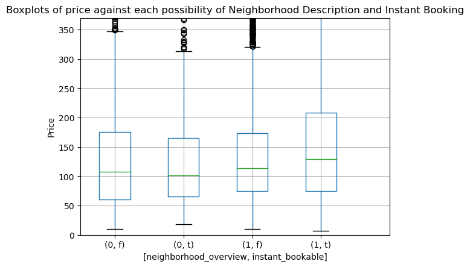

```python
"""
The 2 lines below convert the neighborhood_overview feature, which contains the text of the
neighbourhood description associated with the listing, into a binary feature that indicates
whether or not the listing has a neighbourhood description.
"""
df1=df.copy()
df1['neighborhood_overview'] = df1['neighborhood_overview'].notna().astype(int)


fig, ax = plt.subplots()
df1.boxplot(column='price', by=['neighborhood_overview', 'instant_bookable'], ax=ax)
plt.ylabel('Price')
plt.suptitle('')
plt.title("Boxplots of price against each possibility of Neighborhood Description and Instant Booking")
ax.set_xlim(0.5, 5)
ax.set_ylim(0, 370)
```

Now, the most important decision a host must make prior to listing his property is how he prices it. To that end, we aim to create a model which prices a listing according to its features. In particular, we aim to create a K Nearest Neighbor model based on the features of the data set. However, we need to remove any features that are only possible for listings that have been used before (like reviews_per_month), as this is will be X's first listing.

```python
"""
We, also eliminate any entries with Na values in them. We can afford to eliminate Na values rather than
impute the data because we have a large number of data points (n = 8949).
"""
df = df.dropna()


"""
Here we just do some data cleaning on the "bathrooms_text" feature, as there are some characters that
are getting in the way of the values that we want.
"""
df2=df.copy()
df2['bathrooms_text'] = df2['bathrooms_text'].str.replace(r'[^0-9.]', '', regex=True)
df2['bathrooms_text'] = df2['bathrooms_text'].replace('', np.nan)


"""
Next, we eliminate the features that we talked about earlier (namely, the ones which can't be used
for a first-time host like X).
"""
columns_to_drop=['reviews_per_month',  'calendar_last_scraped','number_of_reviews',
'number_of_reviews_ltm','number_of_reviews_l30d','first_review','last_review','review_scores_rating',
'review_scores_accuracy','review_scores_cleanliness','review_scores_checkin','review_scores_communication',
'review_scores_location','review_scores_value','minimum_minimum_nights','maximum_minimum_nights',
'minimum_maximum_nights','maximum_maximum_nights','minimum_nights_avg_ntm','maximum_nights_avg_ntm',
'amenities','latitude','longitude','host_neighbourhood','host_about','host_response_time',
'host_response_rate','host_acceptance_rate','last_scraped','name','neighborhood_overview','host_since',
'room_type','has_availability' ]
df2 = df2.drop(columns=columns_to_drop)


"""
Finally, we need to convert the categorical variables in our dataset into a form whereby we
can fit our KNN model. Note that we convert the variables into their one-hot form, which will add many
columns to our dataframe.
"""
categorical_variables=["host_is_superhost", "host_verifications", "host_has_profile_pic",
     "host_identity_verified", "neighbourhood_cleansed", "property_type", "instant_bookable"]

for cat in categorical_variables:
    df2 = pd.get_dummies(df2, columns=[cat], drop_first=True)

X= df2.drop(columns=['price'])
```

We are now ready to fit the KNN, but we need a way to pick the best K value in terms of Mean Squared Error. The way we go about doing this is using the k-fold cross validation, with k = 5. The method which will facilitate this tuning of k is called GridSearchCV. After finding the best k, we will use our model to make a prediction on how X should price his property given the information he's given us.

```python
k_grid = {'n_neighbors': range(1, 30)}
knn_model = KNeighborsRegressor()
grid_search = GridSearchCV(knn_model, param_grid=k_grid, cv=5, scoring='neg_mean_squared_error')
grid_search.fit(X, df2['price'])
best_k = grid_search.best_params_['n_neighbors']

knn_model = KNeighborsRegressor(n_neighbors=best_k)
knn_model.fit(X, df2['price'])
```

```
KNeighborsRegressor(n_neighbors=14)
```

```python
"""
We will now build the data point pertaining to X's details, this will be a long object due to
the many dummy variables on our dataframe (which were a result of us converting the catgeorical
variables into their one-hot form). We will then use the data point to make a prediction on what
the price of X's property should be.
"""
X_details=[1, 1, 2, 2, 2, 1, 30, 20, 45, 60, 95, 1, 1, 0, 0, 0, 0, 1, 0, 1, 1]


"""
The next 3 lines are to related to neighbourhood variable, in particular the numbers are what they are
because for the neighbourhood variable X's property belongs to the Chatham category (which
is the 11th category).
"""
X_details += [False] * 10
X_details.append(True)
X_details += [False] * 55


"""
The next 3 lines are to related to property type variable, in particular the numbers are what they are
because for the property type variable X's property belongs to the entire condo category (which
is the 11th category).
"""
X_details.append(True)
X_details += [False] * 33
X_details.append(True)
input_data = np.array([X_details])

input_data_df = pd.DataFrame(input_data)
input_data_df.columns = X.columns

print(knn_model.predict(input_data_df))
```

```
[118.42857143]
```

As we can see, the listing for X's condo on Airbnb should have a price of about $118.

After X is done with his listing we want it to be the case that the person who stayed at his condo leaves behind a positive rating, as this will encourage even more people to stay at his Airbnb. To that end, we need to find out what actions X can take throughout the guest's stay which will encourage the guest to provide a positive rating. The actions we wish to study, in relation to their impact on rating, are: communication with the guest, cleanliness and ease of checking in. Thus, we will do a scatter plot of ratings against each of the aforementioned features.

| feature | correlation |
| --- | --- |
| review_scores_communication | 0.806347 |
| review_scores_cleanliness | 0.737819 |
| review_scores_checkin | 0.681776 |

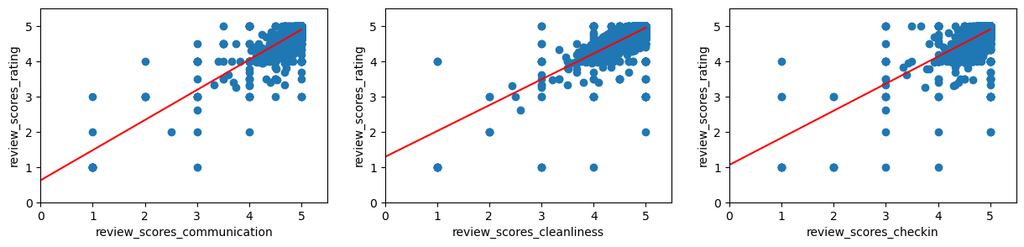

```python
fig, ax = plt.subplots(nrows=1, ncols=3, figsize=(15,3))
actions=["review_scores_communication", "review_scores_cleanliness", "review_scores_checkin"]
correlation={"feature": actions}
values=[]
for i,action in enumerate(actions):
    ax[i].set_xlim(0, 5.5)
    ax[i].set_ylim(0, 5.5)
    ax[i].scatter(df[action], df["review_scores_rating"])
    ax[i].set_ylabel('review_scores_rating')
    ax[i].set_xlabel(action)
    coefficients = np.polyfit(df[action], df["review_scores_rating"], 1)
    line_of_best_fit = np.poly1d(coefficients)
    x_range = np.linspace(0, 5, 100)
    y_fit = line_of_best_fit(x_range)
    ax[i].plot(x_range, y_fit, color="red")
    values.append(df["review_scores_rating"].corr(df[action]))

correlation["correlation"]=values
df4=pd.DataFrame(correlation)
df4.set_index('feature', inplace=True, drop=True)
df4
```

The main takeaway from the plots above is the following: X needs to ensure a smooth check in process, clean up his condo prior to the arrival of the guest and have good communication with the guest throughout his stay (using the app's chat feature). In particular, he should focus on communication the most out of the 3, as it has the highest correlation with respect to ratings.

# Recommendation for Y in Chicago

We begin by loading the Listings file for Chicago. We remove incomplete data to obtain a complete data set.

```python
conn = sqlite3.connect(filepath)
df = pd.read_sql_query("SELECT * FROM 'united-states_chicago_visualisations_listings'", conn)
df = df.drop(columns='neighbourhood_group')
```

Next, we load the Reviews file for Chicago. This allows us to obtain a sentiment score from for each review using the Sentiment Intensity Analyzer from the nltk library.

```python
conn = sqlite3.connect(filepath)

reviews = pd.read_sql_query("SELECT * FROM 'united-states_chicago_data_reviews'", conn)

sid = SentimentIntensityAnalyzer()

def compute_sentiment(text):
    if text is None:
        return 0
    return sid.polarity_scores(str(text))['compound']

reviews['sentiment_score'] = reviews['comments'].apply(compute_sentiment)

conn.close()
```

We now compute the average sentiment score for each listing after removing the sentiment scores of 0. This is done as the sentiment calculation process returns a value of 0 if it cannot identify the text. This is due to the review being in a language other than English.

```python
averaged_reviews = reviews[['listing_id', 'sentiment_score']]
averaged_reviews = averaged_reviews[averaged_reviews['sentiment_score'] != 0]
averaged_reviews = averaged_reviews.groupby('listing_id')['sentiment_score'].mean().reset_index()
```

Lastly, we merge the dataframe containing the average sentiment score with the listings dataframe.

```python
complete_data = pd.merge(averaged_reviews, df, left_on='listing_id', right_on='id', how='right')
complete_data = complete_data.drop(columns=('id'))
complete_data = complete_data[complete_data['sentiment_score'] != 0]
complete_data = complete_data.dropna()
complete_data.columns
```

```
Index(['listing_id', 'sentiment_score', 'name', 'host_id', 'host_name',
       'neighbourhood', 'latitude', 'longitude', 'room_type', 'price',
       'minimum_nights', 'number_of_reviews', 'last_review',
       'reviews_per_month', 'calculated_host_listings_count',
       'availability_365', 'number_of_reviews_ltm', 'license'],
      dtype='object')
```

We begin our analysis by investigating the effect that the room type has on the sentiment score obtained from the reviews.

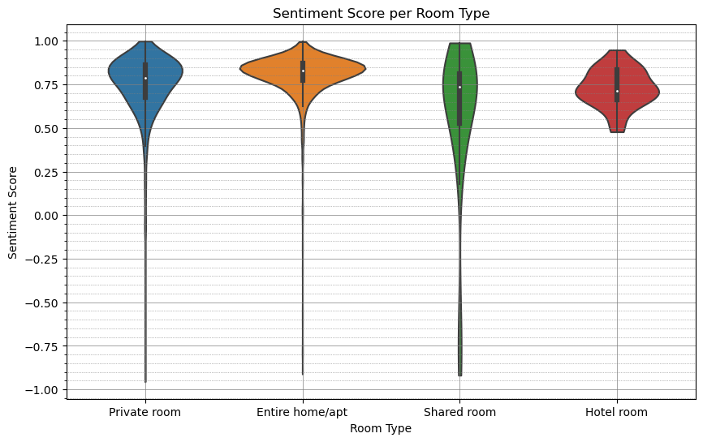

```python
# Create a violin plot for sentiment score per room type
plt.figure(figsize=(10, 6))
ax = sns.violinplot(x='room_type', y='sentiment_score', data=complete_data, cut=0)

# Add title and axis labels
plt.title('Sentiment Score per Room Type')
plt.xlabel('Room Type')
plt.ylabel('Sentiment Score')

# Set the minor locator for y-axis to automatically determine the correct number of minor intervals
ax.yaxis.set_minor_locator(AutoMinorLocator())

# Add horizontal grid lines for both major and minor tick marks
ax.grid(which='major', color='gray', linestyle='-', linewidth=0.5)
ax.grid(which='minor', color='gray', linestyle=':', linewidth=0.5)

# Show the plot
plt.show()
```

Hotel Room: The sentiment for hotel rooms has the most compact distribution, indicating a smaller range of review scores and the highest minimum sentiment score. The median sentiment score is lower compared to the other categories but still above 0.5, suggesting overall positive reviews. It is worth noting that there were no reviews with a sentiment score above 0.95.

Shared Room: Shared rooms shows a narrow and tall distribution, which means that the sentiments are more varied and less concentrated around the median, which is the second lowest. This suggests a great variety in the experiences with shared rooms.

Entire Home/Apartment: The sentiment scores for entire homes and apartments are most tighlty distrubted around its mean just above 0.8. The tight distribution around the mean indicates the most consistent experiences at a high level of satisfaction.

Overall, to maximise the satisfaction of Y, we would recommened booking an entire home due to the highest satisfaction and highest consistency around the mean satisfaction inidcated by the customers sentiment.

We now focus on the area that Y should look in to find an Airbnb listing. The next plot shows an interactive map of Chicago that presents the loctions of all listings and their respective sentiment scores obtained.

```python
entire_home_data = complete_data[complete_data['room_type'] == 'Entire home/apt']
```

```python
# Create a scatter mapbox plot for only entire homes
fig = px.scatter_mapbox(entire_home_data, lat='latitude', lon='longitude',
                        color='sentiment_score',
                        color_continuous_scale='Viridis',
                        size_max=15, zoom=10)

# Update the layout
fig.update_layout(mapbox_style="open-street-map",
                  title='Map of Listings by Sentiment Score')
fig.update_layout(margin={"r":0,"t":0,"l":0,"b":0})

# Show the plot
fig.show()
```

[interactive chart not shown]

Disregarding individual outliers, the map shows no clear areas to avoid for Y. We need a more detailed analysis of the individual neighbourhoods to be able to infer the customer satisfaction from the review sentiment. Below we produce a bar chart showing the average sentiment in each neighbourhood for entiire home listings.

```python
# Calculate mean sentiment score and standard deviation for each neighbourhood
neighbourhood_stats_entire = entire_home_data.groupby('neighbourhood')['sentiment_score'].agg(['mean', 'std', 'count']).reset_index()

# Create a bar chart with the calculated statistics
fig = px.bar(neighbourhood_stats_entire, x='neighbourhood', y='mean',
             hover_data={'mean': ':.3f', 'std': ':.3f', 'count': True},
             labels={'mean': 'Average Sentiment Score', 'std': 'Standard Deviation', 'count': 'Number of Listings'})

# Update layout with title and axis labels
fig.update_layout(title='Average Sentiment Score by Neighbourhood',
                  xaxis_title='Neighbourhood',
                  yaxis_title='Average Sentiment Score',
                  xaxis={'categoryorder':'total descending'},
                  hovermode='closest',
                  xaxis_tickangle=270)  # x-axis labels rotated by 270 degrees (or -90 degrees)

# Show the plot
fig.show()
```

[interactive chart not shown]

As we can see, there is a discrepency in the average sentiment scores across the neighbourhoods. It is important to notice that some neighbourhoods have very few listings. This has two consequences. The first is that with a low number of listings, outliers have a much greater effect. Second, a lower number of listings will make it harder for Y to successfully obtain a booking when he wants to visit. Therefore, we recreate this plot below but remove all neighbourhoods with fewer than 50 listings.

```python
# Filter out neighbourhoods with 50 or fewer listings
neighbourhoods_with_enough_listings_entire = neighbourhood_stats_entire[neighbourhood_stats_entire['count'] > 50]

# Create a bar chart with the filtered statistics
fig = px.bar(neighbourhoods_with_enough_listings_entire, x='neighbourhood', y='mean',
             hover_data={'mean': ':.3f', 'std': ':.3f', 'count': True},
             labels={'mean': 'Average Sentiment Score', 'std': 'Standard Deviation', 'count': 'Number of Listings'})

# Update layout with title and axis labels
fig.update_layout(title='Average Sentiment Score of Entire Homes by Neighbourhood (More than 50 Listings)',
                  xaxis_title='Neighbourhood',
                  yaxis_title='Average Sentiment Score',
                  xaxis={'categoryorder':'total descending'},
                  hovermode='closest',
                  xaxis_tickangle=270)  # x-axis labels rotated by 270 degrees

# Show the plot
fig.show()
```

[interactive chart not shown]

As we can see, North Center, Logan Square, and Edgewater have the highest mean sentiment scores for entire homes with below average standard deviations. Thus Y should be looking for a listing in one of these neighbourhoods. As we have ensured that all the recommended neighbourhoods have more than 50 listings, Y should be able to find one matching his personal preferences too.

Knowing that Y should book an entire home in either North center, Logan Square or Edgewater to maximise his satisfaction, we shall now look at how much money he should spend on his accomodation.

As there is a singular anaomalous priced listing at 100000 dollars a night, this is removed by restricting the maximum price to help visualisation. The following plot looking at the relation between price and sentiment. We use Lowess smoothing to indicate a trend.

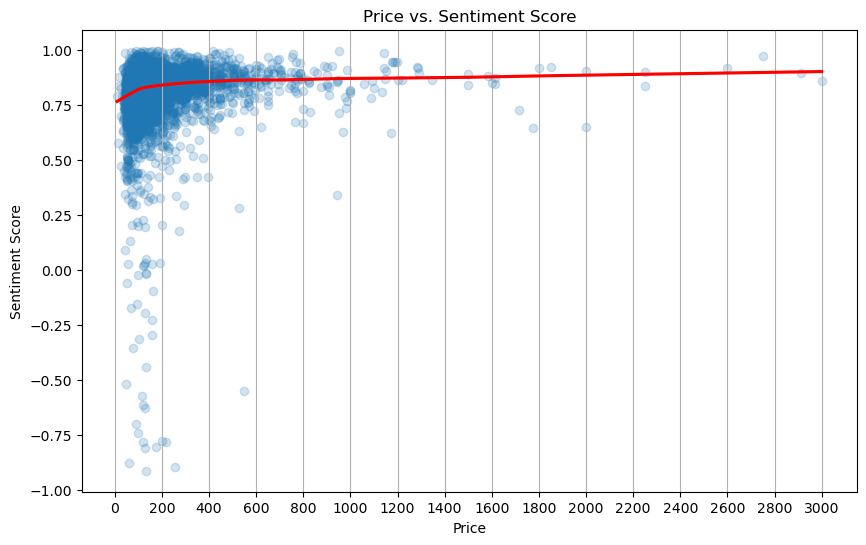

```python
# Filter out listings with prices higher than 20000
filtered_data = entire_home_data[entire_home_data['price'] <= 20000]

# Create a scatter plot with a Lowess smoothed trend line
plt.figure(figsize=(10, 6))
sns.regplot(x='price', y='sentiment_score', data=filtered_data, lowess=True, scatter_kws={'alpha': 0.2}, line_kws={'color': 'red'})

# Set x-ticks at regular intervals
max_price = filtered_data['price'].max()
plt.xticks(np.arange(0, max_price + 1, 200))

# Add vertical grid lines
plt.grid(axis='x')

plt.title('Price vs. Sentiment Score')
plt.xlabel('Price')
plt.ylabel('Sentiment Score')
plt.show()
```

The plot shows a notable increase in mean sentiment between 0 and approximatley 100 dollars, after which the gradient decreases and the rise in sentiment with price shrinks drastically. Once approximatly 200 dollars a night are reached, there are no negative sentiment scores remaining (albeit four outliers) practically elimnating a negative sentiment. We would recommend Y to look for a booking around the 200-400 dollar mark as this seems to maximise the value received. At this mark there is very little risk of an unsatisfactory stay in all neighbourhoods and an increase in the price will not gain any substantial benefit.

Although we have a recommendation for the price to spend in our recommended neighbourhoods, we should check that these general trends of price also hold for the three reccommended neighbourhoods.

To accomplish this we create a 3D plot of price and neighbourhood against senitiment. You can pick an individual Neighbourhood to look at and then select/remove additional neighbourhoods using the crtl key (or the cmd key on mac). Running this cell requires the latest version of plotly ipywidgets. Unfortunatley, the Jupyter extension is unable to render this plot without executing the code first (e.g. after downloading the notebook from GitHub).

We can use this plot to investigate the effect of price in the three reccomendet neighbourhoods (Logan Square, Edgewater, North Center) on sentiment.

```python
# Filter to exclude neighbourhoods with less than 50 listings
filtered_data = filtered_data.groupby('neighbourhood').filter(lambda x: len(x) >= 50)

# Create a unique list of neighborhoods and convert it to a tuple
neighborhoods = tuple(filtered_data['neighbourhood'].unique())

# Create figure
fig = go.FigureWidget()

# Function to update the figure based on the selected neighborhoods
def update_plot(selected_neighborhoods):
    filtered = filtered_data[filtered_data['neighbourhood'].isin(selected_neighborhoods)]
    with fig.batch_update():
        fig.data = []
        for neighborhood in selected_neighborhoods:
            neighborhood_data = filtered[filtered['neighbourhood'] == neighborhood]
            fig.add_scatter3d(x=neighborhood_data['price'], y=neighborhood_data['neighbourhood'],
                              z=neighborhood_data['sentiment_score'], mode='markers',
                              marker=dict(size=5), name=neighborhood)

# Initial plot with all neighborhoods
update_plot(neighborhoods)

# Create a widget for neighborhood selection
neighborhood_selector = widgets.SelectMultiple(
    options=neighborhoods,
    value=neighborhoods,
    description='Neighborhoods',
    disabled=False
)

# Add interaction to the neighborhood selector widget
def on_neighborhood_change(change):
    update_plot(change['new'])

neighborhood_selector.observe(on_neighborhood_change, names='value')

# Update the figure
fig.update_layout(
    width=1000,
    height=600,
    title_text='Effect of Price of Enitire Homes for Neighbourhoods on Satisfaction Score'
)

# Display the widget and the figure
#display(neighborhood_selector)
#display(fig)
```

```python
from plotly.offline import iplot, init_notebook_mode
init_notebook_mode(connected=True)

iplot(fig)
```

[interactive chart not shown]

The plot shows that Loan Square has lower sentiment scores for the same price compared to the other areas. Although the plot also shows great similarity between North Center and Edgewater, North Center has the least negative outliers from its trend. In North Center, Y would be guaranteed a sentiment score of greater than 0.8 when spending around 250 dollars a night. Thus, for a guaranteed great experience, whilst being fiscally responsible, we would recommend Y to look for an entire home lisitng for about 250 and 350 dollars a night in North Center. Moreover, if Y is seeking an exceptional experience, we suggest considering listings priced between 400 and 600 dollars per night in North Center. This recommendation is based on the fact that the lowest score in this category is 0.89, while the highest is 0.99.

# Conclusion

This report provides an insightful exploration into Airbnb's landscape across key North American cities, offering nuanced advice for hosts and travelers alike, drawing from a thorough data-driven analysis. We focus particularly on two individuals: X, who's considering hosting in Chicago, and Y, a visitor to the city. The findings from our data investigation are presented to assist both parties in navigating the Airbnb experience effectively.

For X, who aims to list his condo on Airbnb, we analyzed various factors that influence listing prices. Our findings suggest that including a neighborhood description and enabling instant booking can positively affect the listing's price. Moreover, we developed a K-Nearest Neighbor model to predict an optimal listing price, considering X's condo features. This model suggests a price point of around $118, balancing attractiveness to potential guests with profitability for X. Additionally, we highlighted the importance of host-guest communication, cleanliness, and smooth check-in processes in garnering positive ratings, which are crucial for a successful Airbnb host.

Y's journey in choosing the ideal Airbnb in Chicago involved understanding the correlation between room types, neighborhood choices, price points, and guest satisfaction, as measured by sentiment scores from reviews. Our analysis revealed that entire homes/apartments tend to offer the highest satisfaction, with consistent positive reviews. We recommended North Center, Logan Square, and Edgewater as ideal neighborhoods for Y, based on their high average sentiment scores and the availability of listings. Furthermore, we advised Y to consider listings priced between $250 and $350 per night in North Center for a balanced experience of high satisfaction and reasonable cost. For an exceptional stay, listings priced between $400 and $600 per night in the same neighborhood would be ideal, as indicated by our sentiment analysis.

In conclusion, this report highlights the significance of data-driven decision-making in the Airbnb market. By analyzing various datasets, we provided actionable insights for both hosts and travelers, aiming to enhance their Airbnb experience. Whether it's pricing strategies for hosts or neighborhood and price point considerations for guests, our study offers an outline to navigate the Airbnb market in Chicago.